# Your First Machine Learning Project in Python Step-By-Step

## Introduction

The goal of this assessment is to explore a variety of different supervised machine learning algorithms to explore the Iris classification data set using Python. This will be a summary examination and overview of a number of different techniques and is less concerned with an in-depth examination of the underlying statistical concepts. The more important goal is to explore the use of the Python language and a number of different useful machine learning libraries supported in Python.

Python is a high-level, interpreted programming language that supports multiple design paradigms, such as object-oriented and procedural scripting. Several well developed libraries allow for the scientific computing that supports machine learning and data visualization, such as NumPy, SciPy, and Pandas.

## Data Collection and Preparation

The Iris data set contains 150 observations of four numeric features and one categorical factor, the species of the flower being observed. The relatively small size of the data set, and the easily interpreted scope of the features makes the Iris data set ideal for basic exploration of different machine learning models.

Python allows us to load the data directly from the UCI Machine Learning repository. We will also take this opporunity to import a number of the libraries that will be used during the assessment:

```python
# Load libraries
import pandas
from pandas.tools.plotting import scatter_matrix
import matplotlib.pyplot as plt
from sklearn import cross_validation
from sklearn.metrics import classification_report
from sklearn.metrics import confusion_matrix
from sklearn.metrics import accuracy_score
from sklearn.linear_model import LogisticRegression
from sklearn.tree import DecisionTreeClassifier
from sklearn.neighbors import KNeighborsClassifier
from sklearn.discriminant_analysis import LinearDiscriminantAnalysis
from sklearn.naive_bayes import GaussianNB
from sklearn.svm import SVC

url = "https://archive.ics.uci.edu/ml/machine-learning-databases/iris/iris.data"
names = ['sepal-length', 'sepal-width', 'petal-length', 'petal-width', 'class']
dataset = pandas.read_csv(url, names=names)
```

First we declared a variable to contain the URL where the data set resides, then we intialized a list of column names that correspond to the feature names. Then we made use of the Pandas library to read the data in from CSV format and applied our list of names to indicate the column/feature names.

To being exploring the data we will check the distribution of the data, the summary statistics for each of the features, and the distribution of the class variable, species:

```python
# shape
print(dataset.shape)

# head
print(dataset.head(20))

# descriptions
print(dataset.describe())
```

```
(150, 5)
    sepal-length  sepal-width  petal-length  petal-width        class
0            5.1          3.5           1.4          0.2  Iris-setosa
1            4.9          3.0           1.4          0.2  Iris-setosa
2            4.7          3.2           1.3          0.2  Iris-setosa
3            4.6          3.1           1.5          0.2  Iris-setosa
4            5.0          3.6           1.4          0.2  Iris-setosa
5            5.4          3.9           1.7          0.4  Iris-setosa
6            4.6          3.4           1.4          0.3  Iris-setosa
7            5.0          3.4           1.5          0.2  Iris-setosa
8            4.4          2.9           1.4          0.2  Iris-setosa
9            4.9          3.1           1.5          0.1  Iris-setosa
10           5.4          3.7           1.5          0.2  Iris-setosa
11           4.8          3.4           1.6          0.2  Iris-setosa
12           4.8          3.0           1.4          0.1  Iris-setosa
13           4.3          3.0           1.1          0.1  Iris-setosa
14           5.8          4.0           1.2          0.2  Iris-setosa
15           5.7          4.4           1.5          0.4  Iris-setosa
16           5.4          3.9           1.3          0.4  Iris-setosa
17           5.1          3.5           1.4          0.3  Iris-setosa
18           5.7          3.8           1.7          0.3  Iris-setosa
19           5.1          3.8           1.5          0.3  Iris-setosa
       sepal-length  sepal-width  petal-length  petal-width
count    150.000000   150.000000    150.000000   150.000000
mean       5.843333     3.054000      3.758667     1.198667
std        0.828066     0.433594      1.764420     0.763161
min        4.300000     2.000000      1.000000     0.100000
25%        5.100000     2.800000      1.600000     0.300000
50%        5.800000     3.000000      4.350000     1.300000
75%        6.400000     3.300000      5.100000     1.800000
max        7.900000     4.400000      6.900000     2.500000
```

By printing the dataset shape, we can easily see how many observations and features. We also printed the first 20 observations in the dataset to get a quick look at some of the feature values. Finally, the describe() method allowed us to print the summary statistics which are useful in data preparation.

The numeric features appear to have a close range of values along the same scale. Before fitting any models, we will also want to check the distribution of our class feature:

```python
# class distribution
print(dataset.groupby('class').size())
```

```
class
Iris-setosa        50
Iris-versicolor    50
Iris-virginica     50
dtype: int64
```

The species feature is evenly distributed with exactly 50 observations of each factor level.

### Data Visualization

In addition to gathering basic statistical summaries, we can also construct some helpful data visualizations. We will take a look at both univariate and multivariate plots to understand each attribute, and the relationships between them.

Box-and-whisker plots and histograms can provide good visualizations of the distribution of numeric features:

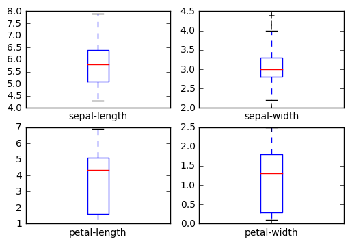

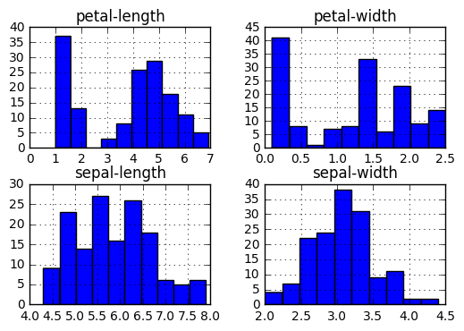

```python
# box and whisker plots
dataset.plot(kind='box', subplots=True, layout=(2,2), sharex=False, sharey=False)
plt.show()

# histograms
dataset.hist()
plt.show()
```

It appears the sepal-length and sepal-width each have a normal or Gaussian distribution; however, the other features do not. This is worth noting as we move into model fitting and evaluation.

Scatterplots allow for examination of any structured relationships that may exist between features that could not otherwise be observed from numeric output alone:

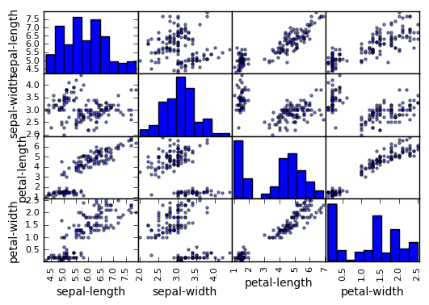

```python
# scatter plot matrix
scatter_matrix(dataset)
plt.show()
```

Several features appear to have strong positive correlations, including petal-length and petal-width as well as sepal-length and pedal-width.

## Model Fitting

Before fitting any algorithmic models, we will have to separate out a validation set for model fitting and improvement, and specify a sampling strategy for iterating models. We will follow a basic 80/20 split by using 80% of the data to train and fit models, leaving 20% for testing once a model has been selected. For resampling we will use a standard 10-fold cross-validation method. This will further split our train data set into 10 subsets, using nine for modeling fitting and one other for validation prior to turning the model loose on the unseen test data set.

```python
# Split-out validation dataset
array = dataset.values
X = array[:,0:4]
Y = array[:,4]
validation_size = 0.20
seed = 7
X_train, X_validation, Y_train, Y_validation = cross_validation.train_test_split(X, Y, test_size=validation_size, random_state=seed)

# Test options and evaluation metric
num_folds = 10
num_instances = len(X_train)
seed = 7
scoring = 'accuracy'
```

In addition to subsetting our original data set and setting up our cross-validation parameters, we also set a variable (scoring) to a value of accuracy. This variable will be used to inform our models that accuracy should be used as the method for assessing model performance.

Accuracy simply refers to the number of correctly classified instances of the class variable that can be expressed as a raw percentage.

For modeling fitting we will be examining six different model types, logistic regression, linear discrimination analysis, k-nearest neighbors, classification and regression trees, Naive Bayes, and Support Vector Machines. A list of our model types is initialized as well as a list to hold results and the name of each model:

```python
# Spot Check Algorithms
models = []
models.append(('LR', LogisticRegression()))
models.append(('LDA', LinearDiscriminantAnalysis()))
models.append(('KNN', KNeighborsClassifier()))
models.append(('CART', DecisionTreeClassifier()))
models.append(('NB', GaussianNB()))
models.append(('SVM', SVC()))
# evaluate each model in turn
results = []
names = []
for name, model in models:
	kfold = cross_validation.KFold(n=num_instances, n_folds=num_folds, random_state=seed)
	cv_results = cross_validation.cross_val_score(model, X_train, Y_train, cv=kfold, scoring=scoring)
	results.append(cv_results)
	names.append(name)
	msg = "%s: %f (%f)" % (name, cv_results.mean(), cv_results.std())
	print(msg)
```

```
LR: 0.966667 (0.040825)
LDA: 0.975000 (0.038188)
KNN: 0.983333 (0.033333)
CART: 0.975000 (0.038188)
NB: 0.975000 (0.053359)
SVM: 0.991667 (0.025000)
```

A standard for loop allowed us to iterate over our list of models, fitting each one at a time. A seed value (which was set earlier, 7) ensures that each model is built using the exact same data splits to ensure that results of each can be directly comparable.

Our for loop fitted each model using the resampling method and subsets we specified earlier and printed the model name, accuracy, and the standard deviation for each model results.

We can plot the model results to show the spread and mean accuracy for each model:

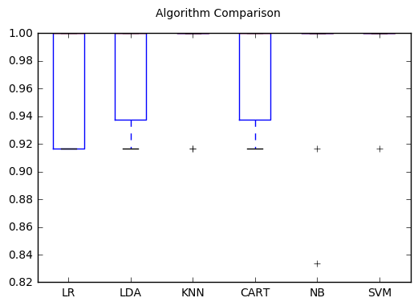

```python
# Compare Algorithms
fig = plt.figure()
fig.suptitle('Algorithm Comparison')
ax = fig.add_subplot(111)
plt.boxplot(results)
ax.set_xticklabels(names)
plt.show()
```

## Prediction

```python
# Make predictions on validation dataset
knn = KNeighborsClassifier()
knn.fit(X_train, Y_train)
predictions = knn.predict(X_validation)
print(accuracy_score(Y_validation, predictions))
print(confusion_matrix(Y_validation, predictions))
print(classification_report(Y_validation, predictions))
```

```
0.9
[[ 7  0  0]
 [ 0 11  1]
 [ 0  2  9]]
             precision    recall  f1-score   support

Iris-setosa       1.00      1.00      1.00         7
Iris-versicolor       0.85      0.92      0.88        12
Iris-virginica       0.90      0.82      0.86        11

avg / total       0.90      0.90      0.90        30
```

From the output, we can see that our kNN model predicted Iris species with 90% accuracy. The resulting confusion matrix shows where the model made errors in prediction.

Finally, we also printed a classification report which shows precision, recall, f1-score, and support.

All metrics are quite promising, but a relatively small data set could be providing overly optimistic results.

## Conclusion

One can see from the relatively small amount of code used above, that effective machine learning models can be constructed, trained, and evaluated without much effort. We were able to assess six different models with minimal effort or code required.

This assessment merely scratches the surface of Python's effectiveness in creating machine learning models, but should be a good showcase of how quickly effective models can be created.